# Data Viz for Shiny App

Clarissa

3/17/2022

## Agency Analysis: Comparison Graphs

### Race x distance traveled

#### (Option 1)

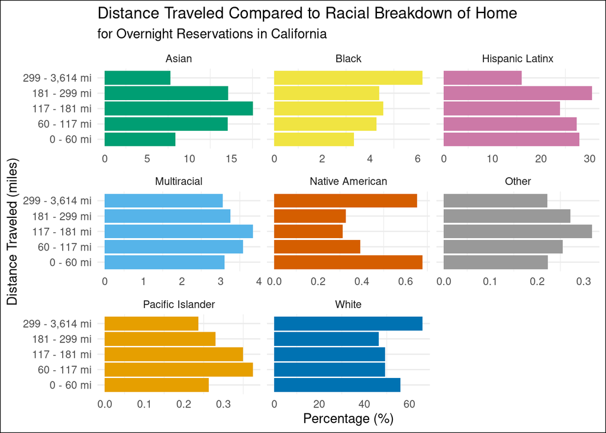

#### (Option 2.1)

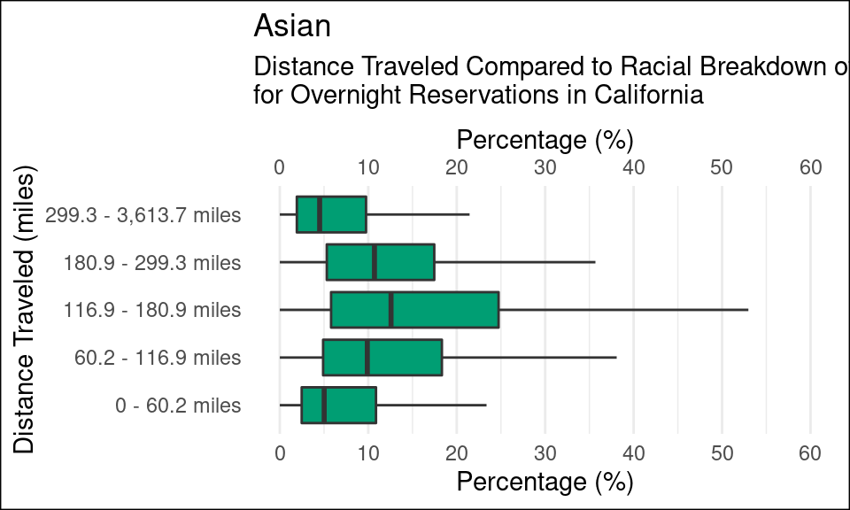

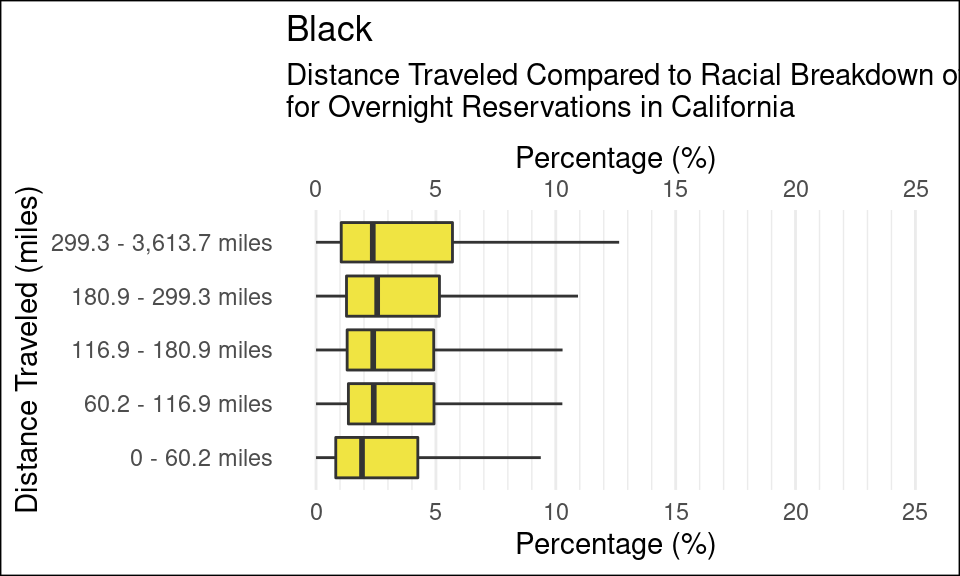

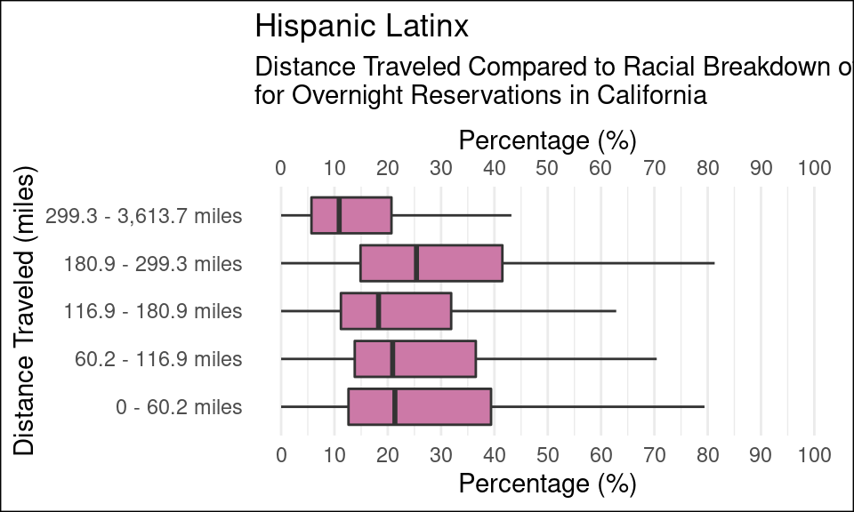

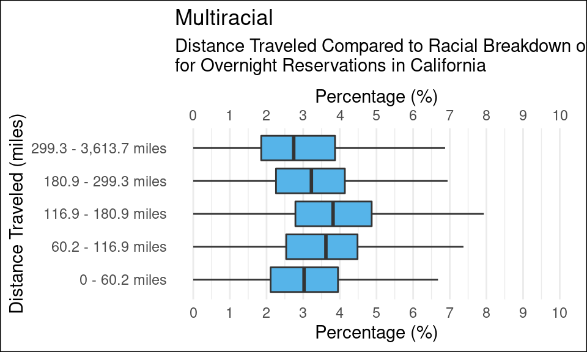

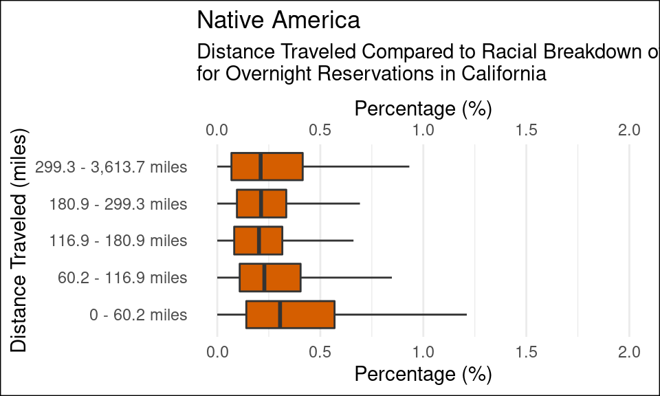

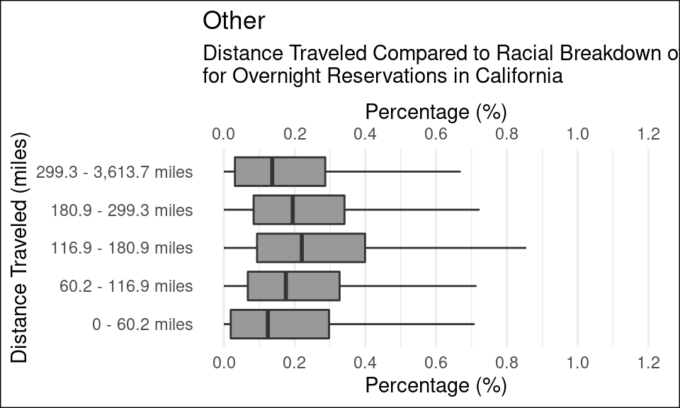

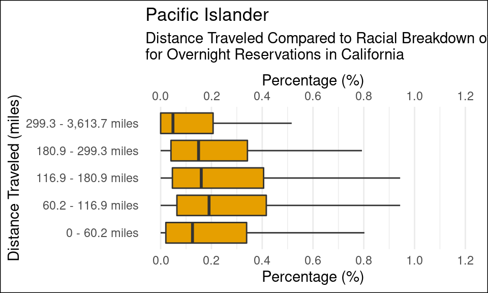

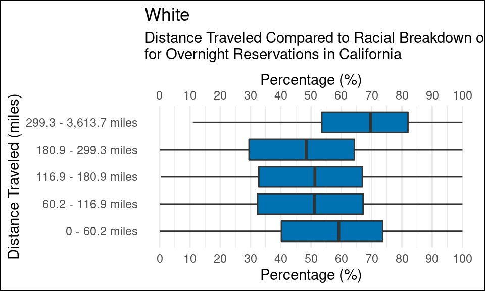

#### (Option 2.2)

[figure not shown]

[figure not shown]

[figure not shown]

[figure not shown]

[figure not shown]

[figure not shown]

[figure not shown]

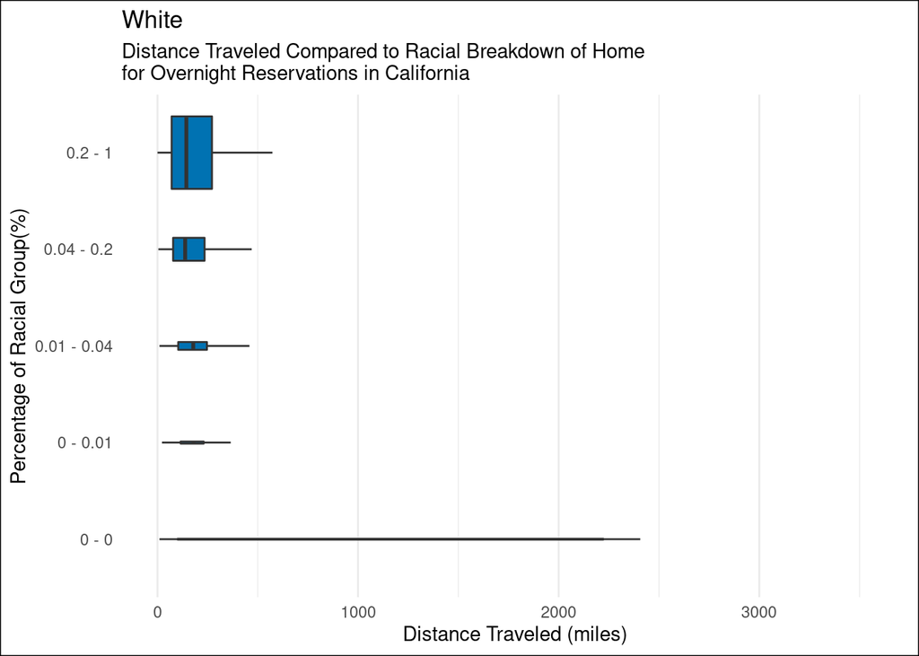

#### (Option 3)

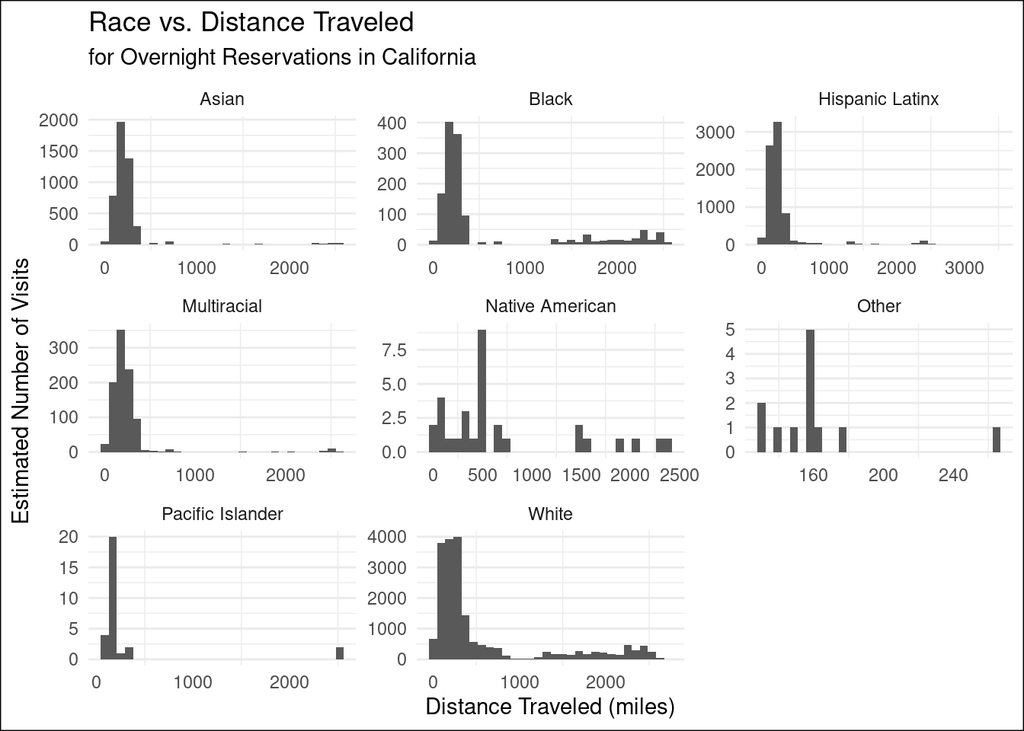

### Race x site type

#### (Option 1)

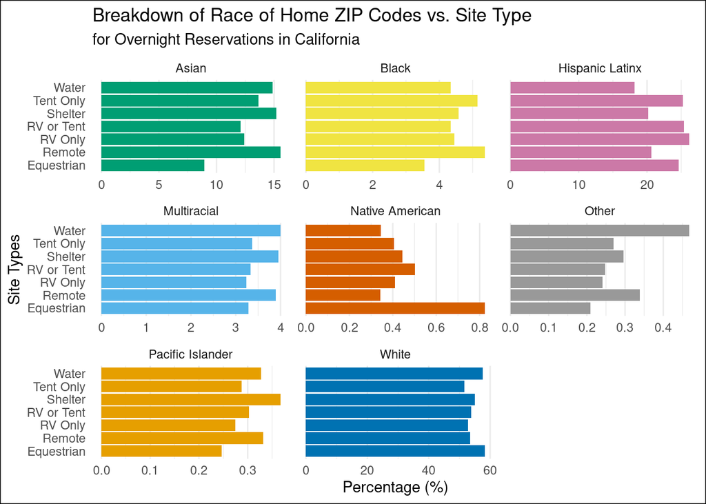

#### (Option 2)

Box plots similar to above

#### (Option 3)

Combination of bar chart with lighter box plot on top

### Race x booking window

#### (Option 1)

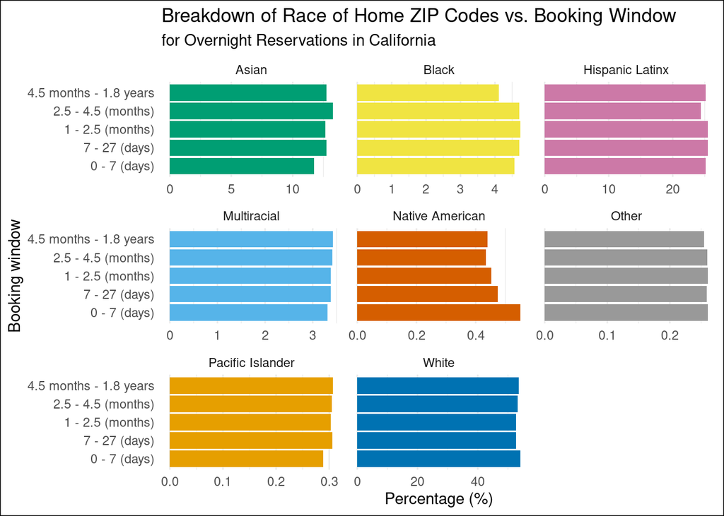

#### (Option 2)

Box plots similar to above

#### (Option 3)

Combination of bar chart with lighter box plot on top

### Race x daily cost

#### (Option 1)

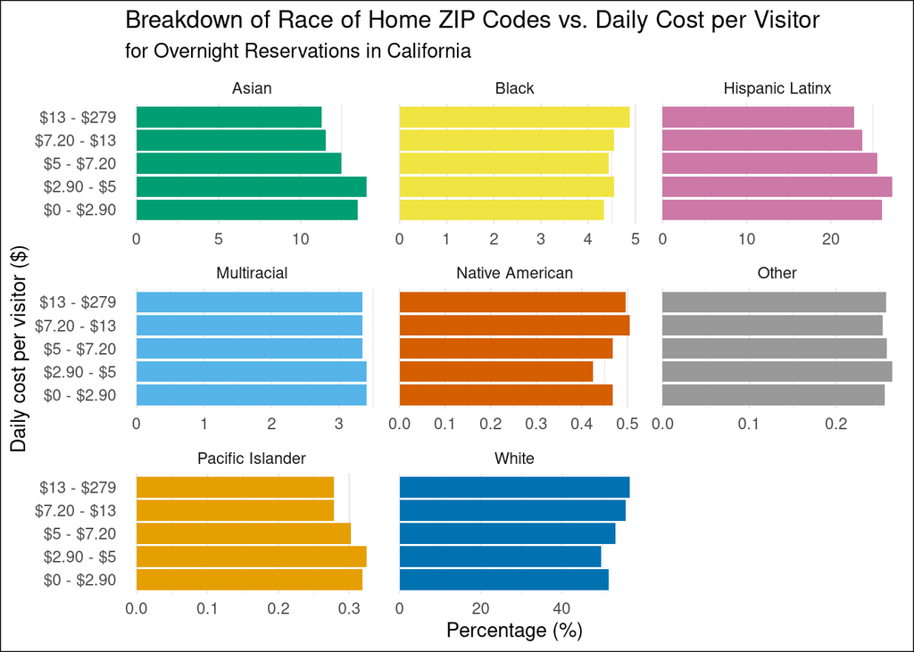

#### (Option 2)

Box plots similar to above

#### (Option 3)

Combination of bar chart with lighter box plot on top

### Race x length of stay

#### (Option 1)

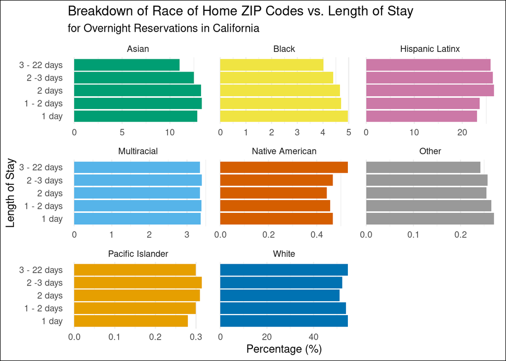

#### (Option 2)

Box plots similar to above

#### (Option 3)

Combination of bar chart with lighter box plot on top

### Education x distance traveled

#### (Option 1)

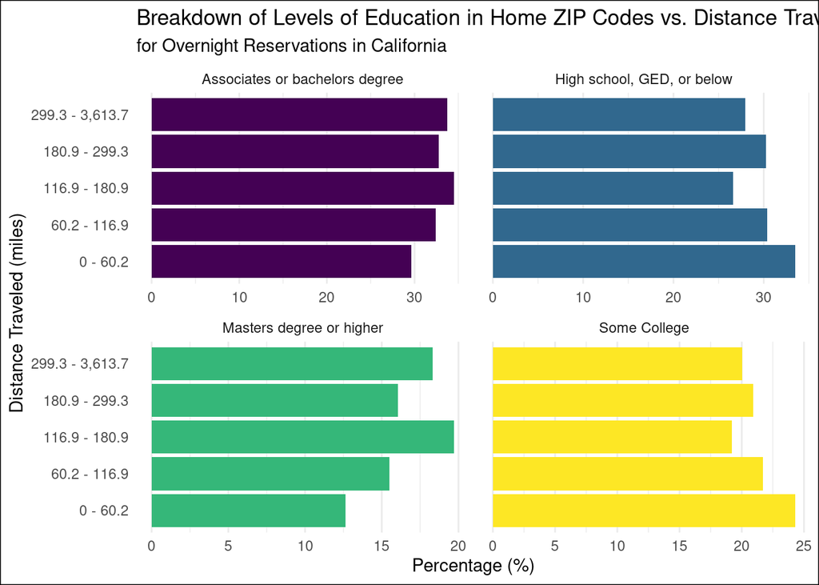

#### (Option 3)

Combination of bar chart with lighter box plot on top

### Education x site type

#### (Option 1)

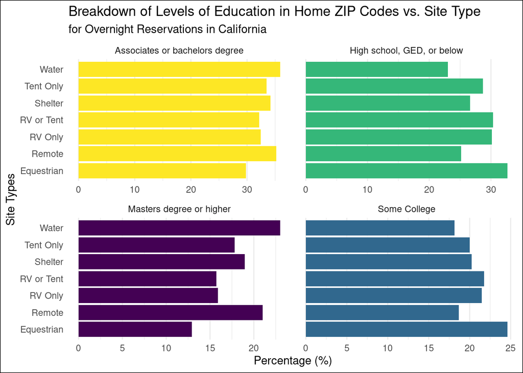

#### (Option 2)

Box plots similar to above

#### (Option 3)

Combination of bar chart with lighter box plot on top

### Education x booking window

#### (Option 1)

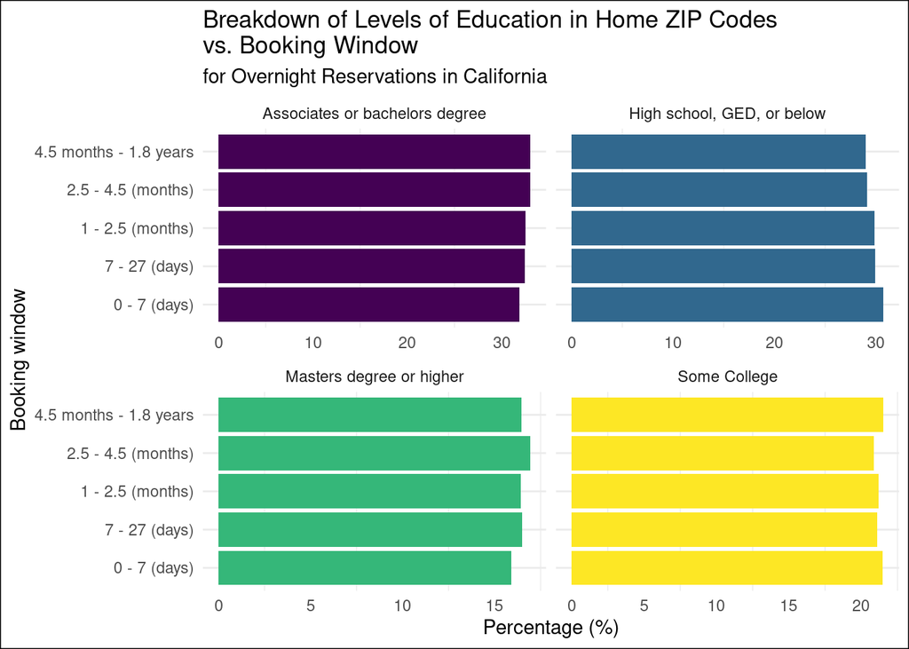

#### (Option 2)

Box plots similar to above

#### (Option 3)

Combination of bar chart with lighter box plot on top

### Education x daily cost

#### (Option 1)

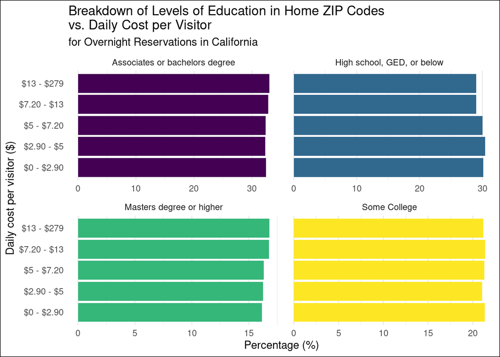

#### (Option 2)

Box plots similar to above

#### (Option 3)

Combination of bar chart with lighter box plot on top

### Education x length of stay

#### (Option 1)

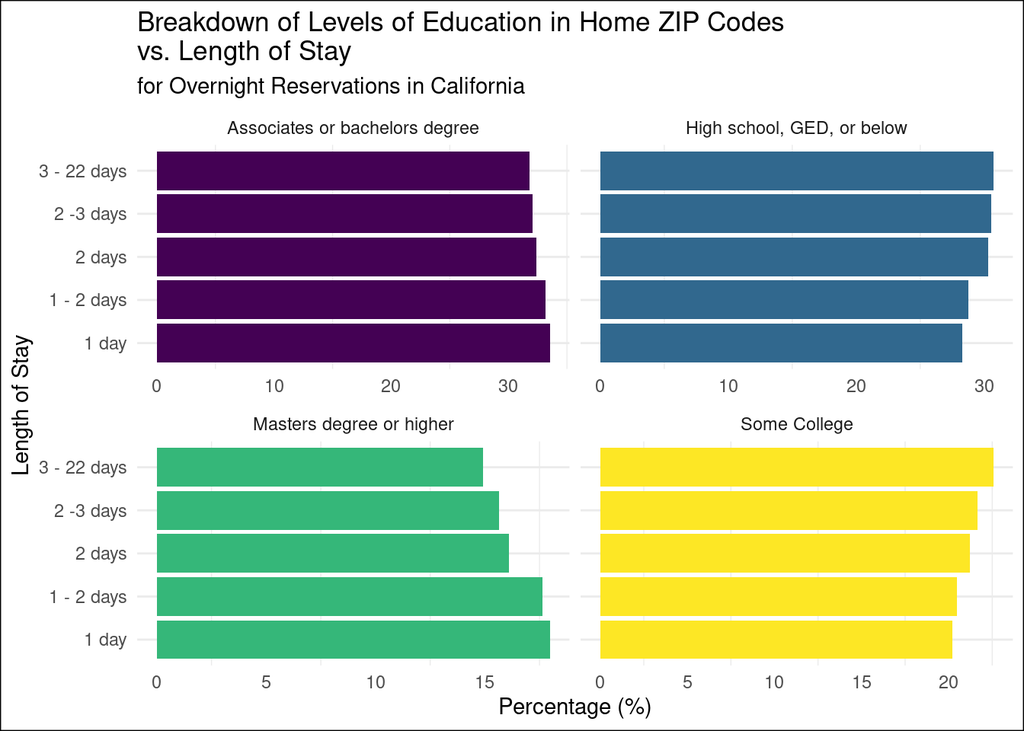

#### (Option 2)

Box plots similar to above

#### (Option 3)

Combination of bar chart with lighter box plot on top

### Language

Similar graphs to those above would exist for:

- Language x distance traveled
- Language x site type
- Language x booking window
- Language x daily cost
- Language x length of stay

### Median-income x distance traveled

Similar graphs to those above would exist for:

- Median-income x distance traveled
- Median-income x site type
- Median-income x booking window
- Median-income x daily cost
- Median-income x length of stay

### Booking window x site type

[figure not shown]

### Booking window x distance traveled

Similar graphs to those above would exist for booking window x distance traveled

```
## Time difference of 1.39692 mins
```